# ggplot2 Graphics

### Faceting- I

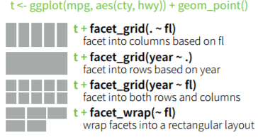

### Faceting - II

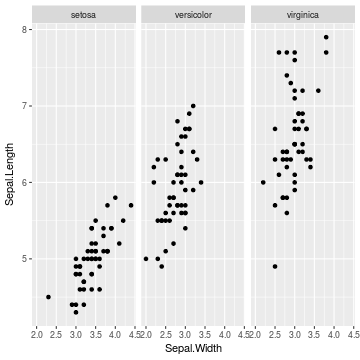

```r
ggplot(iris, aes(Sepal.Width,Sepal.Length)) +
  geom_point() +
  facet_grid(.~Species)
```

### Faceting - III

Adjustments

- scales
- labels

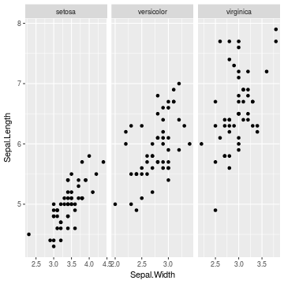

```r
ggplot(iris, aes(Sepal.Width,Sepal.Length)) +
  geom_point() +
  facet_grid(.~Species,scales="free")
```

### Scales - I

Scales control how a plot maps data values to visual values of an aesthetic.

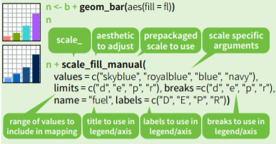

### Scales - II

```r
scale_fill_discrete(name="Tested species", labels = c("Setosa","Versicolor","Virginica"))
```

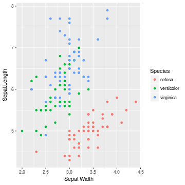

```r
ggplot(iris, aes(Sepal.Width,Sepal.Length, colour=Species)) +
  geom_point() +
  scale_fill_discrete(name="Tested species", labels = c("Setosa","Versicolor","Virginica"))
```

### Scales - III

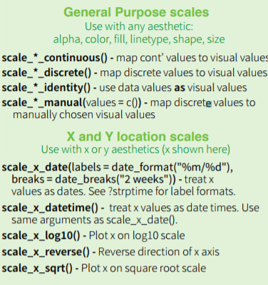

[figure not shown]

### Themes - I

Available themes

```r
theme_gray()
```

```r
theme_bw()
```

```r
theme_classic()
```

ggthemes Package

### Themes - II

Within every theme there are elements

```r
line = element_line()
rect = element_rect()
text = element_text()
axis.line.x = element_blank()
axis.tick =
legend.background = element_rect()
panel.background =
strip.placement.y =
plot.caption =
```

[Find all elements here](https://github.com/tidyverse/ggplot2/blob/master/R/theme-defaults.r)

### Themes - III

Within each element you can change Similar to base plot

- size
- colour
- linetype
- margins
- …and much more

[For more inspiration](https://github.com/tidyverse/ggplot2/blob/master/R/theme-defaults.r)

### Putting graphs together - I

Every ggplot object can be given a name

```r
plot1 = ggplot(iris, aes(Species,Sepal.Length)) +
  geom_boxplot()

plot2 = ggplot(iris, aes(Sepal.Width,Sepal.Length, col=Species)) +
  geom_point()
```

Using gridExtra

```r
library(grid)
library(gridExtra)
```

### Putting graphs together - II

```r
grid.arrange(plot1, plot2, plot1,
             ncol=2,
             top="General title",
             bottom = "General x axis",
             left = " General y axis",
             right = "General 2nd y axis")
```

(sorry, this somehow failed incorporate in R presentation) More complex layouts are possible

[Link](https://cran.r-project.org/web/packages/gridExtra/vignettes/arrangeGrob.html)

### Some handy functions - I

Returning the last plot

```r
last_plot()
```

Saving a plot (last plot)

```r
ggsave("plot.png",width=5,height = 5)
```

*(size is in inch)*

### Some handy functions - II

**qplot vs ggplot** ggplot

```r
ggplot(iris, aes(Sepal.Width,Sepal.Length,col=Species)) +
  geom_point()
```

qplot

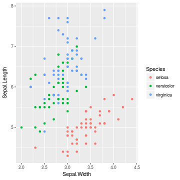

```r
qplot(x=Sepal.Width,y=Sepal.Length,col=Species,data=iris,geom="point")
```